# Toxic Comment Classification Challenge

João Duro

April 1, 2018

# 1. Introduction

Nowadays, having conversations online can be tough. The anonymous factor makes people express themselves much more aggressive than they would in real life. Be on a comment section from a YouTube video, or on a discussion about an article from a newspaper, or online video games, this problem is frequent and platforms have difficulty in dealing with this problem.

The goal of this project is to build a model to detects different types of toxicity like threats, obscenity, insults, and identity hate, based on text data.

# 2. Preparation, File Stucture and Content

For this analysis we will mostly need data manipulation packages, visualization packages and model.

```r
set.seed(1)
#setwd(dirname(rstudioapi::getActiveDocumentContext()$path))
library(data.table)
library(dplyr)
library(tidyr)
library(tidytext)
library(tm)
library(SnowballC)
library(tibble)

library(ggplot2)
library(grid)
library(wordcloud)
library(ggridges)

library(xgboost)
```

We are given a training data set ‘train’, which consists of a set of comments classified with the type of toxicity they display, and a test set which we intend to classify having or not these types of toxicity problems.

We load both data sets and follow with a quick look into the sets to see their shape

```r
train      <- fread("train.csv"            , header=TRUE)
test       <- fread("test.csv"             , header=TRUE)
subm       <- fread("sample_submission.csv", header=TRUE)

train[,id:=.I]
test[ ,id:=(nrow(train)+1):(nrow(train)+nrow(test))]

glimpse(train)
```

```
## Observations: 95,851
## Variables: 8
## $ id            <int> 1, 2, 3, 4, 5, 6, 7, 8, 9, 10, 11, 12, 13, 14, 1...
## $ comment_text  <chr> "Nonsense?  kiss off, geek. what I said is true....
## $ toxic         <int> 1, 0, 0, 0, 0, 0, 0, 0, 0, 0, 0, 0, 0, 0, 0, 0, ...
## $ severe_toxic  <int> 0, 0, 0, 0, 0, 0, 0, 0, 0, 0, 0, 0, 0, 0, 0, 0, ...
## $ obscene       <int> 0, 0, 0, 0, 0, 0, 0, 0, 0, 0, 0, 0, 0, 0, 0, 0, ...
## $ threat        <int> 0, 0, 0, 0, 0, 0, 0, 0, 0, 0, 0, 0, 0, 0, 0, 0, ...
## $ insult        <int> 0, 0, 0, 0, 0, 0, 0, 0, 0, 0, 0, 0, 0, 0, 0, 0, ...
## $ identity_hate <int> 0, 0, 0, 0, 0, 0, 0, 0, 0, 0, 0, 0, 0, 0, 0, 0, ...
```

```r
head(train$comment_text)
```

```
## [1] "Nonsense?  kiss off, geek. what I said is true.  I'll have your account terminated."
## [2] "\"\"\r\n\r\n Please do not vandalize pages, as you did with this edit to W. S. Merwin. If you continue to do so, you will be blocked from editing.    \"\""
## [3] "\"\"\r\n\r\n \"\"\"\"Points of interest\"\"\"\" \r\n\r\nI removed the \"\"\"\"points of interest\"\"\"\" section you added because it seemed kind of spammy. I know you probably didn't mean to disobey the rules, but generally, a point of interest tends to be rather touristy, and quite irrelev…
## [4] "Asking some his nationality is a Racial offence. Wow wasn't aware of it.  Blocking me has shown your support towards your community. Thanku for that"
## [5] "The reader here is not going by my say so for ethereal vocal style and dark lyrical content. The cited sources in the External Links are saying those things. If you feel the sources are unreliable or I did not represent what they said correctly rewrite or delete it."
## [6] "Fried chickens \r\n\r\nIs dat sum fried chickens?"
```

```r
glimpse(test)
```

```
## Observations: 153,164
## Variables: 2
## $ id           <int> 95852, 95853, 95854, 95855, 95856, 95857, 95858, ...
## $ comment_text <chr> "Yo bitch Ja Rule is more succesful then you'll e...
```

In the next sections, we will explore the train data set a bit.

# 3. Exploration of toxicity problems

We know that a text can be both toxic and a threat at the same time, so it’s important we see the distribution of the number of problems per text. Lets just hope we have very few texts with a lot of problems…

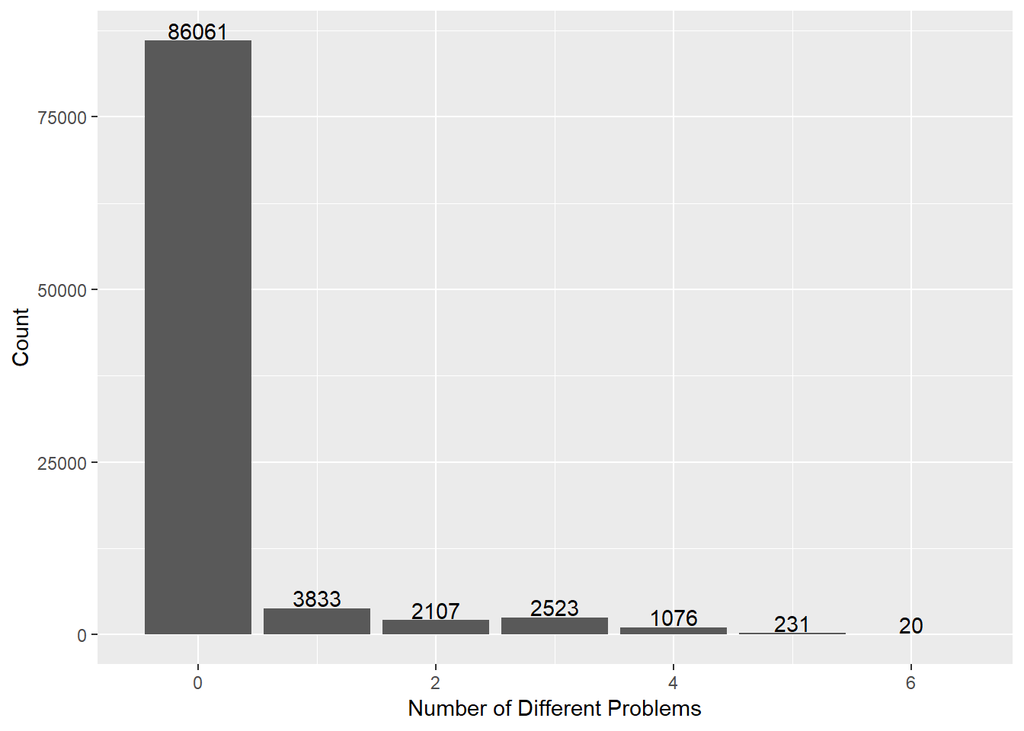

```r
train[,inci:=as.integer(toxic+severe_toxic+obscene+threat+insult+identity_hate)]
ggplot(train, aes(x = inci)) +
  geom_bar(width = 0.9) +
stat_bin(binwidth= 1,geom="text", aes(label=..count..),vjust = -0.1)+
  labs(x = "Number of Different Problems", y="Count")
```

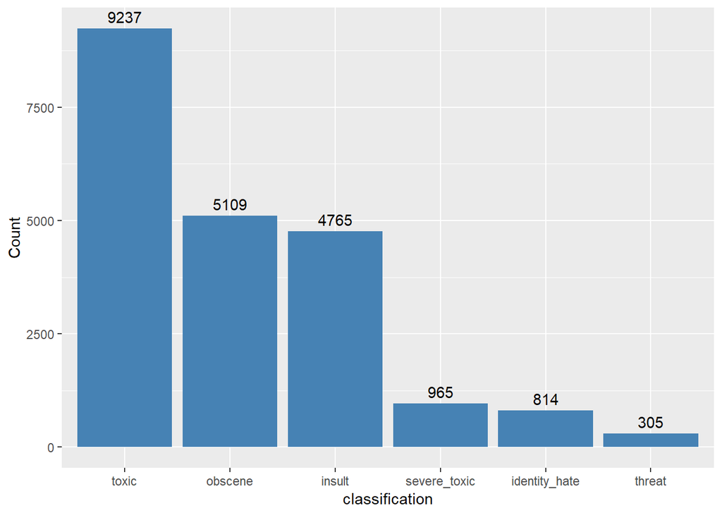

```r
dfm <- data.table(classification=names(train[,3:8]), n=apply(train[,3:8],2,sum)) %>%
  mutate(classification=reorder(classification,-n))
ggplot(dfm, aes(x=classification, y=n))+
  geom_bar(stat="identity", fill="steelblue")+
  geom_text(aes(label=n),vjust = -0.5)+
  labs(y="Count")
```

```r
rm(dfm)

a<-data.frame(
sapply(train[toxic==1        ,3:8],sum),
sapply(train[severe_toxic==1 ,3:8],sum),
sapply(train[obscene==1      ,3:8],sum),
sapply(train[threat==1       ,3:8],sum),
sapply(train[insult==1       ,3:8],sum),
sapply(train[identity_hate==1,3:8],sum)
)
rownames(a)<-names(train[,3:8]);colnames(a)<-names(train[,3:8])

a;rm(a)
```

```
##               toxic severe_toxic obscene threat insult identity_hate
## toxic          9237          965    4797    289   4445           751
## severe_toxic    965          965     921     75    833           178
## obscene        4797          921    5109    198   3739           612
## threat          289           75     198    305    200            64
## insult         4445          833    3739    200   4765           675
## identity_hate   751          178     612     64    675           814
```

The last table shows us how many texts display a certain problem and display another one. One take we can take from this is that for example, all texts that display ‘severe toxicity’ also display ‘toxicity’ problems.

# 4. Unnest words - Most used words per category

We will make use of the ‘unnest_tokens’ from the package tidytext to tokenize our texts. We remove the stop words since these would make it harder to detect the most important patterns in our data.

```r
train$comment_text <-gsub("[^a-zA-Z]"," ",train[,comment_text])

data<-unnest_tokens(train, word, comment_text)%>%
  anti_join(stop_words,by="word")%>%
  mutate(num_ch=nchar(word))%>%
  as.data.table()

data %>%
  count(word) %>%
  arrange(-n)
```

```
## # A tibble: 124,845 x 2
##    word          n
##    <chr>     <int>
##  1 article   34464
##  2 wikipedia 29361
##  3 page      28246
##  4 talk      22927
##  5 don       14207
##  6 edit      11230
##  7 people    11013
##  8 articles  10180
##  9 time       9544
## 10 user       8918
## # ... with 124,835 more rows
```

The most used words don’t spike us any particular interest. Since most of our texts didn’t display any problem, it was expected that we we wouldn’t see any hateful words among the most used, since then the texts would be classified with some toxicity type.

We can instead see which words are most used within each category with the following visual:

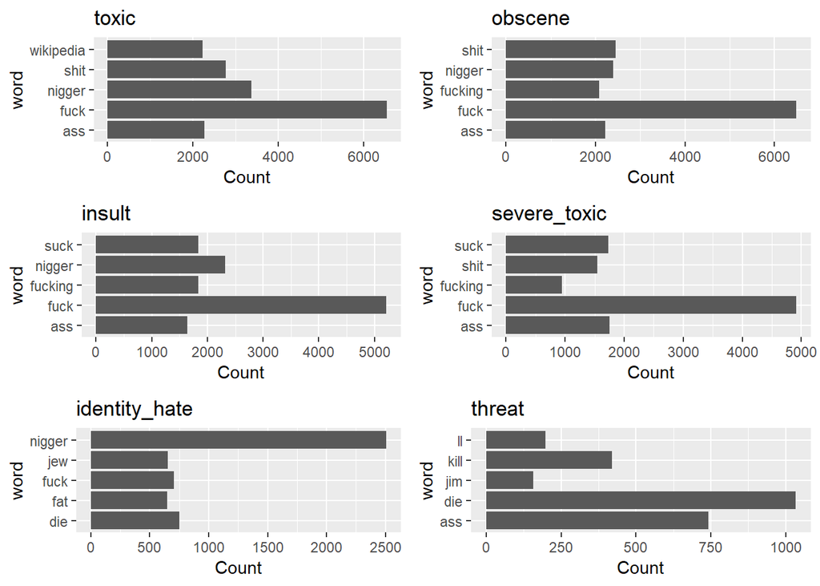

```r
p1<-
data %>%
  filter(toxic==1) %>%
  count(word) %>%
  arrange(-n) %>%
  top_n(5) %>%
  ggplot(aes(x=word,y=n))+
  geom_col()+
coord_flip() +
ggtitle("toxic") +
  labs(y="Count")

p2<-
  data %>%
  filter(obscene==1) %>%
  count(word) %>%
  arrange(-n) %>%
  top_n(5) %>%
  ggplot(aes(x=word,y=n))+
  geom_col()+
  coord_flip()  +
  ggtitle("obscene") +
  labs(y="Count")

p3<-
data %>%
  filter(insult==1) %>%
  count(word) %>%
  arrange(-n) %>%
  top_n(5) %>%
  ggplot(aes(x=word,y=n))+
  geom_col()+
  coord_flip() +
  ggtitle("insult")+
  labs(y="Count")

p4<-
data %>%
  filter(severe_toxic==1) %>%
  count(word) %>%
  arrange(-n) %>%
  top_n(5) %>%
  ggplot(aes(x=word,y=n))+
  geom_col()+
  coord_flip()  +
  ggtitle("severe_toxic") +
  labs(y="Count")

p5<-
data %>%
  filter(identity_hate==1) %>%
  count(word) %>%
  arrange(-n) %>%
  top_n(5) %>%
  ggplot(aes(x=word,y=n))+
  geom_col()+
  coord_flip()  +
  ggtitle("identity_hate") +
  labs(y="Count")

p6<-
data %>%
  filter(threat==1) %>%
  count(word) %>%
  arrange(-n) %>%
  top_n(5) %>%
  ggplot(aes(x=word,y=n))+
  geom_col()+
  coord_flip()  +
  ggtitle("threat") +
  labs(y="Count")

layout <- matrix(c(1,2,3,4,5,6),3,2,byrow=TRUE)
multiplot(p1, p2, p3,p4,p5,p6, layout=layout)
```

```r
rm(p1, p2, p3,p4,p5,p6,layout)
```

We start to grasp some idea of what defines each category. We see that the word “nigger” is very used in “identity hate” comments, and for example the word “die” appears in the comments categorized as “threat”. Some words like “fuck” are used a lot in most categories, with the exception of the “threat”.

We can look for a pattern on the comments length to see if this relates to a text being toxic or not. Maybe when we’re being toxic we tend to say something longer or maybe we just simply say what we gotta say and it’s concise.

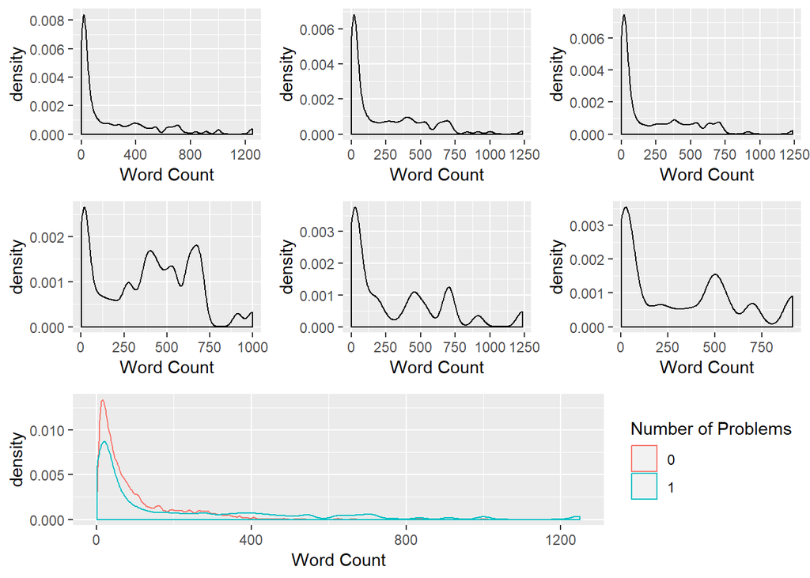

```r
p1<-
  data %>%
   group_by(id) %>%
   mutate(cn=length(id))%>%
   filter(toxic==1)%>%
   ggplot(aes(cn))+
   geom_density() +
  labs(x="Word Count")

p2<-
  data %>%
  group_by(id) %>%
  mutate(cn=length(id))%>%
  filter(obscene==1)%>%
  ggplot(aes(cn))+
  geom_density() +
  labs(x="Word Count")

p3<-
  data %>%
  group_by(id) %>%
  mutate(cn=length(id))%>%
  filter(insult==1)%>%
  ggplot(aes(cn))+
  geom_density() +
  labs(x="Word Count")

p4<-
  data %>%
  group_by(id) %>%
  mutate(cn=length(id))%>%
  filter(severe_toxic==1)%>%
  ggplot(aes(cn))+
  geom_density() +
  labs(x="Word Count")

p5<-
  data %>%
  group_by(id) %>%
  mutate(cn=length(id))%>%
  filter(identity_hate==1)%>%
  ggplot(aes(cn))+
  geom_density() +
  labs(x="Word Count")

p6<-
  data %>%
  group_by(id) %>%
  mutate(cn=length(id))%>%
  filter(threat==1)%>%
  ggplot(aes(cn))+
  geom_density() +
  labs(x="Word Count")

p7<-
  data %>%
  group_by(id) %>%
  mutate(cn=length(id))%>%
  mutate(inci=ifelse(inci==0,0,1))%>%
  ggplot(aes(cn,group=as.character(inci), color=as.character(inci)))+
  geom_density() +
  labs(x="Word Count")+
  labs(x="Word Count",color = "Number of Problems")

layout <- matrix(c(1,2,3,4,5,6,7,7,7),3,3,byrow=TRUE)
multiplot(p1, p2, p3,p4,p5,p6,p7, layout=layout)
```

```r
rm(p1, p2, p3,p4,p5,p6,p7,layout)
```

# 5. Bi-grams

The most used words per category might be interesting, and we might find some words that define certain categories. But perhaps the combination of words might be even more determining of the problem.

We can do the same analysis as before, but now we work with pairs of words. We first unnest the training data set, and we follow by removing the pairs that contain stop words.

```r
data_bi<-unnest_tokens(train, bigram, comment_text,token = "ngrams",n=2) #

data_bi<- separate(data_bi,bigram,c("word1","word2"))

data_bi<-
  data_bi %>%
  filter(!(word1 %in% stop_words$word)) %>%
  filter(!(word2 %in% stop_words$word)) %>%
  unite(bigram, word1, word2, sep = " ") %>%
  as.data.table()


data_bi %>%
  count(bigram) %>%
  arrange(-n)
```

```
## # A tibble: 486,234 x 2
##    bigram              n
##    <chr>           <int>
##  1 talk page        8088
##  2 nigger nigger    2721
##  3 speedy deletion  2652
##  4 http www         1960
##  5 feel free        1437
##  6 talk contribs    1388
##  7 wikipedia org    1322
##  8 talk pages       1306
##  9 en wikipedia     1274
## 10 pig pig          1249
## # ... with 486,224 more rows
```

We look now to see if there’s a bigram that clearly defines a certain category.

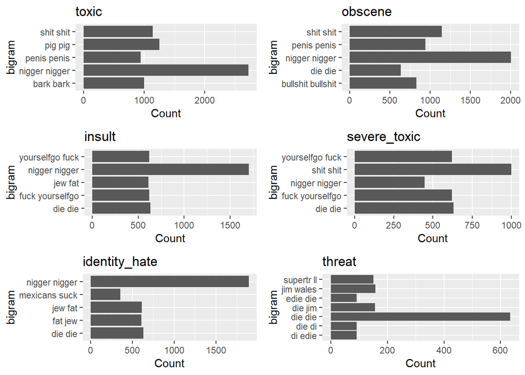

```r
p1<-
  data_bi %>%
  filter(toxic==1) %>%
  count(bigram) %>%
  arrange(-n) %>%
  top_n(5) %>%
  ggplot(aes(x=bigram,y=n))+
  geom_col()+
  coord_flip() +
  ggtitle("toxic")+
  labs(y="Count")

p2<-
  data_bi %>%  #palavras mais usadas
  filter(obscene==1) %>%
  count(bigram) %>%
  arrange(-n) %>%
  top_n(5) %>%
  ggplot(aes(x=bigram,y=n))+
  geom_col()+
  coord_flip()  +
  ggtitle("obscene")+
  labs(y="Count")

p3<-
  data_bi %>%  #palavras mais usadas
  filter(insult==1) %>%
  count(bigram) %>%
  arrange(-n) %>%
  top_n(5) %>%
  ggplot(aes(x=bigram,y=n))+
  geom_col()+
  coord_flip() +
  ggtitle("insult")+
  labs(y="Count")

p4<-
  data_bi %>%  #palavras mais usadas
  filter(severe_toxic==1) %>%
  count(bigram) %>%
  arrange(-n) %>%
  top_n(5) %>%
  ggplot(aes(x=bigram,y=n))+
  geom_col()+
  coord_flip()  +
  ggtitle("severe_toxic")+
  labs(y="Count")

p5<-
  data_bi %>%  #palavras mais usadas
  filter(identity_hate==1) %>%
   count(bigram) %>%
  arrange(-n) %>%
  top_n(5) %>%
  ggplot(aes(x=bigram,y=n))+
  geom_col()+
  coord_flip()  +
  ggtitle("identity_hate")+
  labs(y="Count")

p6<-
  data_bi %>%  #palavras mais usadas
  filter(threat==1) %>%
  count(bigram) %>%
  arrange(-n) %>%
  top_n(5) %>%
  ggplot(aes(x=bigram,y=n))+
  geom_col()+
  coord_flip()  +
  ggtitle("threat")+
  labs(y="Count")

layout <- matrix(c(1,2,3,4,5,6),3,2,byrow=TRUE)
multiplot(p1, p2, p3,p4,p5,p6, layout=layout)
```

```r
rm(p1, p2, p3,p4,p5,p6,layout,data_bi)
```

# 6. Sentiment Analysis

Every word has a meaning and it can have a positive or negative interpretation. Each document might have both positive and negative words but if the negative words outweigh the positive, we can expect the presence of some sort of toxicity.

```r
data<-
data %>%
  merge(get_sentiments("bing"), by = "word", all.x = T)%>%
  as.data.table


data[,sentiment:=ifelse(sentiment=='positive',1,-1)]

data[sentiment==-1,SenNeg:=sum(sentiment,na.rm=T),by=id]
data[sentiment==1 ,SenPos:=sum(sentiment,na.rm=T),by=id]
```

Since we’re dealing with text that does not come strictly from books or magazines, we can expect a lot of grammar mistakes. But most important, we should note that most words have a neuter meaning. For this reason, I expect that the sentiment package will not be able to make a perfect match and not give a value for some words.

```r
100*sum(data[,is.na(sentiment)])/nrow(data)
```

```
## [1] 88.21318
```

Unfortunately we only have a sentiment for 12% of the words present on our text. Nonetheless, we can see how it toxic or not some of the documents are depending on their overall sentiment.

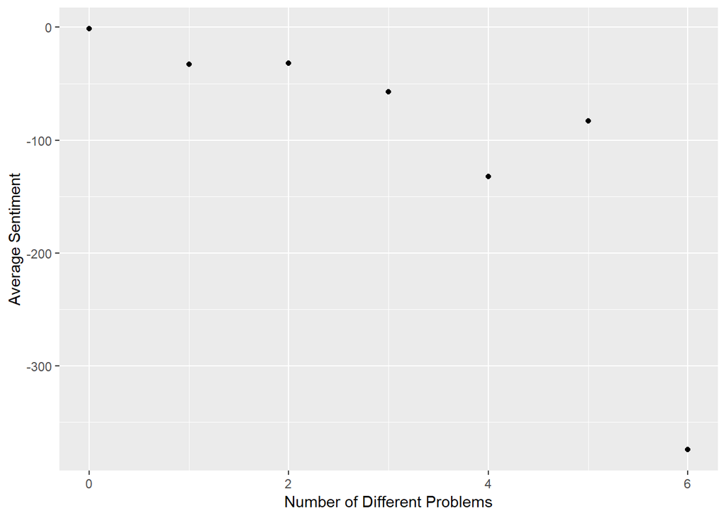

```r
data[,.(sum(sentiment,na.rm = T),inci),by="id"][,mean(V1),by=inci]%>%
  ggplot(aes(x=inci,y=V1))+
  geom_point()+
  labs(x = "Number of Different Problems", y="Average Sentiment")
```

We expected that the more negative overall a text is, the more problems of toxicity it displays. That is evident for the texts that display all of the problems, but overall we can see that the more negative it is, the more problems.

In fact, we can see the average of texts that display problems and the texts that don’t.

```r
data.table(Condition=c("No Problem","Problem"),AverageSentiment=c(
data[inci==0,.(sum(sentiment,na.rm = T)),by="id"][,mean(V1)],
data[inci>0,.(sum(sentiment,na.rm = T)),by="id"][,mean(V1)]))
```

```
##     Condition AverageSentiment
## 1: No Problem       -0.4665842
## 2:    Problem       -4.4436836
```

Clearly the documents that do display some sort of toxicity have an average sentiment much more negative than the texts that don’t display any of our problems.

```r
data.table(Problems=c("toxic","severe_toxic","obscene","threat","insult","identity_hate"),AverageSentiment=c(
data[toxic==1,.(sum(sentiment,na.rm = T)),by="id"][,mean(V1)],
data[severe_toxic==1,.(sum(sentiment,na.rm = T)),by="id"][,mean(V1)],
data[obscene==1,.(sum(sentiment,na.rm = T)),by="id"][,mean(V1)],
data[threat==1,.(sum(sentiment,na.rm = T)),by="id"][,mean(V1)],
data[insult==1,.(sum(sentiment,na.rm = T)),by="id"][,mean(V1)],
data[identity_hate==1,.(sum(sentiment,na.rm = T)),by="id"][,mean(V1)]))
```

```
##         Problems AverageSentiment
## 1:         toxic        -4.551295
## 2:  severe_toxic       -16.577801
## 3:       obscene        -5.771205
## 4:        threat        -8.537705
## 5:        insult        -5.511550
## 6: identity_hate        -6.263547
```

If we see the average per group, we see that the texts that display ‘severe toxicity’ or ‘threat’ have an average sentiment less than the other groups, which was to be expected.

# 7. Feature Engineering

We combine both our data sets in order to derive the necessary features of each text. We clean the text from any character which is not a letter and remove the stop words. This should make our ‘Document Term Matrix’ smaller.

```r
data <-
train %>%
  select(-c(toxic, severe_toxic, obscene, threat, insult, identity_hate)) %>%
  bind_rows(test)%>%
  mutate(comment_text=gsub("[^a-zA-Z]"," ",comment_text))%>%
  unnest_tokens(word, comment_text)%>%
  anti_join(stop_words,by="word")%>%
  merge(get_sentiments("bing"), by = "word", all.x = T)%>%
  mutate(sentiment=ifelse(sentiment=='positive',1,-1))%>%
  mutate(num_ch=nchar(word))%>%
  as.data.table
```

The features we add are the number of words in the text, the average length of each word, the maximum character of any word in the text, the overall sentiment of the text, the number of “positive” words, and number of ‘negative’.

We create these variables in order to add them to our DTM later.

```r
variables<-
  data[,.(txt_len=.N,
          AverChar=mean(num_ch),
          MaxChar=max(num_ch),
      Sentiment= sum(sentiment,na.rm=T)
        ,SenNeg= sum(sentiment==-1,na.rm=T)
        ,SenPos= sum(sentiment== 1,na.rm=T))
     ,by=id]
```

# 8. Document Term Matrix

A document-term matrix is a matrix where each row represents a document and each column a term, and the entries of this matrix represent the number of times each term appears in each document. It is used to describe the frequency of terms per document. We can either use the number of term frequency or the ‘tf-idf’, which stands for ‘term frequency-inverse document frequency’.

We now create the dtm for our collection of texts.

```r
freq <-
  data %>%
  mutate(word=wordStem(word))%>%
  filter(15>num_ch & num_ch>2)%>%
  count(id, word)

dtm <-
  cast_sparse(freq,id, word, n)
dim(dtm);rm(data)
```

```
## [1] 246648 198854
```

We have our ‘document term matrix’ with the frequency of each word for each document. The dimensions of this matrix are the number of documents by the number of unique words in all documents.

Furthermore, we combine the variables we had calculated the chapter before with this matrix.

```r
dtm <-
  cbind(dtm,as.matrix(variables[id %in% freq$id][order(id)]));rm(variables)
```

It’s important to point out that there’s some documents from our initial train and test data sets that do not appear in this matrix. This is because some documents after cleaning and filtering for words with only number of letters between 2 and 15 displayed no words and so we don’t use them for training and for prediction we will predict them as not displaying no problems.

For the document number 1 and 20, the variables 5,6,10,12 are:

```r
dtm[c(1,20),c(5,6,10,12)]
```

```
## 2 x 4 sparse Matrix of class "dgCMatrix"
##    termin true merwin vandal
## 1       1    1      .      .
## 20      .    .      .      2
```

# 9. Model, parameters, XGBOOST

One of the most popular and talked models nowadayson Kaggle has to be the xgBoost (short for ‘extreme gradient boosting’) and it’s the one we will use now.

In order to create our predictive models we must first split our matrix into two, corresponding to the train and test data.

```r
subm[ ,id_N:=(nrow(train)+1):(nrow(train)+nrow(test))]
subm_new<-subm[id_N %in% freq$id,]

index<-c(1:nrow(train[id %in% freq$id]))
X<-dtm[index,]
X_test <-dtm[-index,];rm(dtm)
```

The main parameter we have to fix is the evaluation metric. For this competition the submissions were evaluated on the mean of the individual AUC(under the curve) of each predicted column.

We can and we had to, tune the parameters in order to achieve a reasonable and satisfying error.

```r
targets <- c("toxic", "severe_toxic", "obscene", "threat", "insult", "identity_hate")

parameters <- list(objective        = "binary:logistic",
                   booster          = "gbtree",
                   eval_metric      = "auc",
                   nthread          = 5,
                   eta              = 0.2,
                   max_depth        = 5,
                   min_child_weight = 5,
                   subsample        = 1,
                   colsample_bytree = 0.7)

i=1
for (target in targets) {
  cat("\nFitting", target, "...\n")
  y <- train[id %in% freq$id][[target]]
  m_xgb <- xgboost(X[,!(colnames(X) %in% c("id"))], y, params = parameters, print_every_n = 500, nrounds = 1000)

  subm_new[[target]] <-predict(m_xgb, X_test[,!(colnames(X) %in% c("id"))])

  assign(paste("f",i,sep=""),as.tibble(xgb.importance(feature_names = colnames(X[,!(colnames(X) %in% c("id"))]), model = m_xgb)))
  i<-i+1
}
```

```
##
## Fitting toxic ...
##
## Fitting severe_toxic ...
##
## Fitting obscene ...
##
## Fitting threat ...
##
## Fitting insult ...
##
## Fitting identity_hate ...
```

# 10. Feature Importance

We’ve built six models, one for each target variable. As we saw before, some words are more associated with specific toxicity problems and as such these models will have different features. Below we can see for each model some of their most important features:

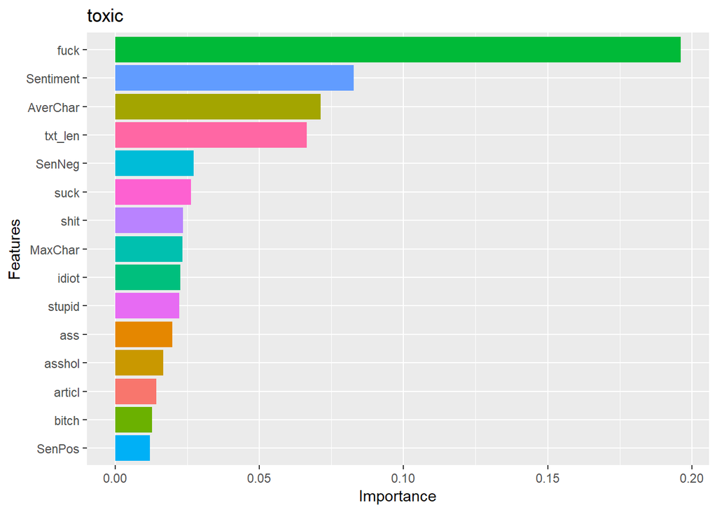

```r
  f1%>%
  top_n(15, Gain) %>%
  ggplot(aes(reorder(Feature, Gain, FUN = max), Gain, fill = Feature)) +
  geom_col() +
  coord_flip() +
  theme(legend.position = "none") +
  labs(title = targets[1],x = "Features", y = "Importance")
```

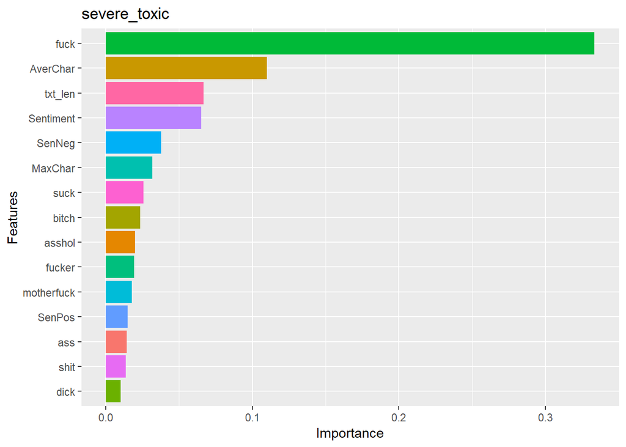

```r
  f2%>%
  top_n(15, Gain) %>%
  ggplot(aes(reorder(Feature, Gain, FUN = max), Gain, fill = Feature)) +
  geom_col() +
  coord_flip() +
  theme(legend.position = "none") +
  labs(title = targets[2],x = "Features", y = "Importance")
```

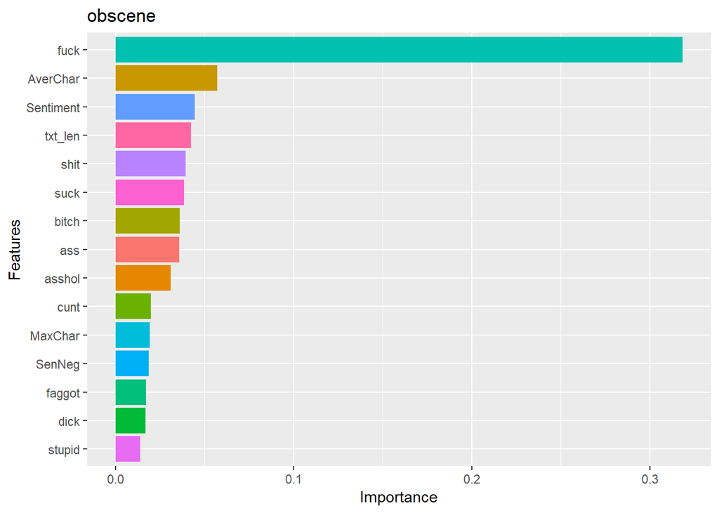

```r
  f3%>%
  top_n(15, Gain) %>%
  ggplot(aes(reorder(Feature, Gain, FUN = max), Gain, fill = Feature)) +
  geom_col() +
  coord_flip() +
  theme(legend.position = "none") +
  labs(title = targets[3],x = "Features", y = "Importance")
```

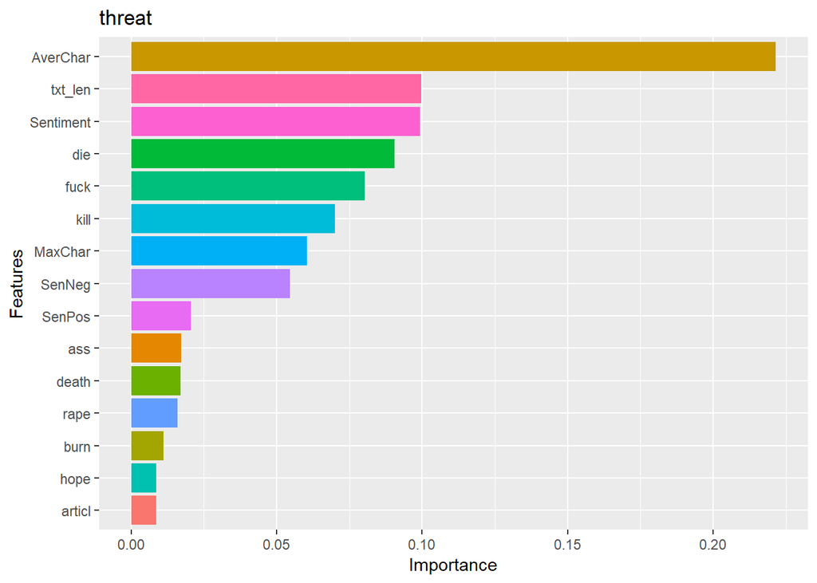

```r
  f4%>%
  top_n(15, Gain) %>%
  ggplot(aes(reorder(Feature, Gain, FUN = max), Gain, fill = Feature)) +
  geom_col() +
  coord_flip() +
  theme(legend.position = "none") +
  labs(title = targets[4],x = "Features", y = "Importance")
```

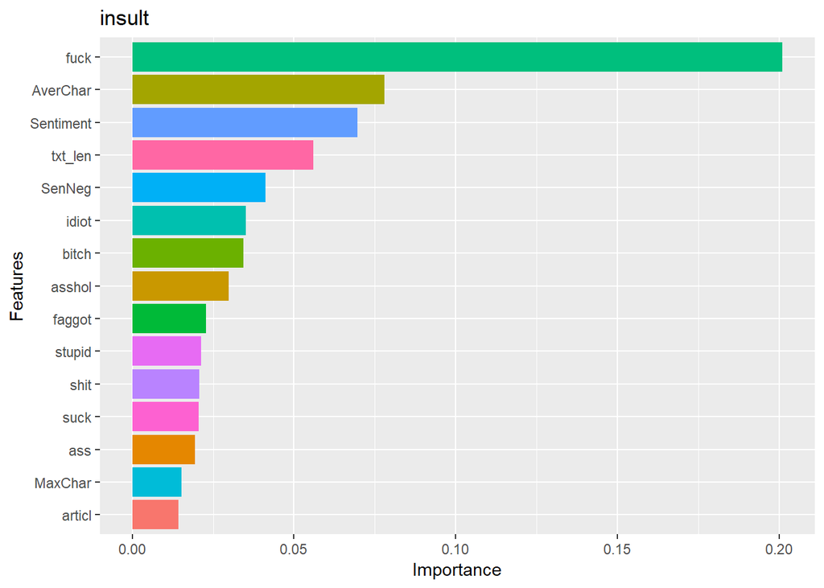

```r
  f5%>%
  top_n(15, Gain) %>%
  ggplot(aes(reorder(Feature, Gain, FUN = max), Gain, fill = Feature)) +
  geom_col() +
  coord_flip() +
  theme(legend.position = "none") +
  labs(title = targets[5],x = "Features", y = "Importance")
```

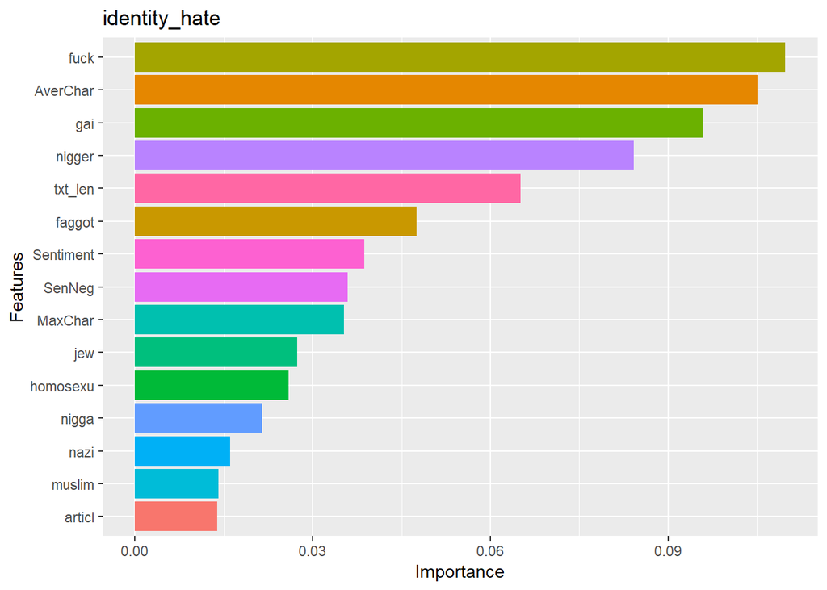

```r
  f6%>%
  top_n(15, Gain) %>%
  ggplot(aes(reorder(Feature, Gain, FUN = max), Gain, fill = Feature)) +
  geom_col() +
  coord_flip() +
  theme(legend.position = "none") +
  labs(title = targets[6],x = "Features", y = "Importance")
```

```r
rm(f1,f2,f3,f4,f5,f6)
```

# 11. Prediction and Submission

With the target variables predicted for most of the texts, we just need to combine the rows we had very little information to predict to our submission file.

```r
nrow(subm_new)+nrow(subm[!(id_N %in% freq$id),] )==nrow(test)
```

```
## [1] TRUE
```

```r
subm_new<-rbind(subm_new,subm[!(id_N %in% freq$id),])
setorder(subm_new,id_N)
subm_new<-subm_new[,-c("id_N")]

#fwrite(subm_new,"sub2.csv")
```

# 12. Conclusion and Future Work

Prior to this project I had no experience working with text data, so this was made with the intent to get myself familiarized with some NLP packages and have some fun.

There are a lot of things I could have tried, like working with td-idf instead of the term frequency for the dtm (document-term matrix), or somehow incorporate a POS-tagger (part-of-speech tagger).

The most important thing to do in my opinion would have been to spend a lot of time on cleaning the text data. I tried to make it cleaner by removing all the non-letter characters and removing the stop words, but there’s still a lot of grammar mistakes that if corrected, would for sure help with our prediction goal.